# Italy’s innovation capacity in a European comparison

2026-07-28

## Italy’s innovation capacity in a European comparison

Measuring a country’s innovation capacity with a single number is inevitably reductive. However, a useful indicator for an initial comparison is **research and development intensity**, defined as gross domestic expenditure on R&D as a share of GDP.

This indicator shows how many resources an economy devotes to producing new knowledge and developing new applications. It does not directly measure the quality of research, the number of innovations introduced to the market, or their economic productivity. It should therefore be interpreted mainly as a measure of a country’s **capacity to invest in innovation**.

Using Eurostat data, we compare Italy, Spain, France, and Germany over the decade from 2014 to 2024.

In 2024, among the four countries considered, the highest R&D intensity was recorded by **Germany**, where expenditure amounted to **3.13% of GDP**. Italy ranked **4**, with a value of **1.38%**.

Compared with 2014, Italy’s R&D intensity changed by **+0.05 percentage points**. This figure helps us assess not only Italy’s current distance from the other large European Union economies, but also the direction it has taken over the decade.

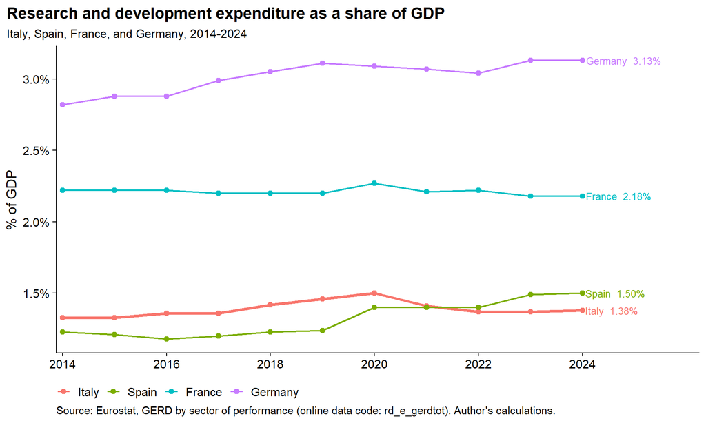

R&D intensity should nevertheless be considered alongside other indicators, including research personnel, patents, collaboration between universities and businesses, the diffusion of digital technologies, and companies’ ability to turn knowledge into new products and processes. From this perspective, the Eurostat indicator is a useful starting point rather than a definitive ranking of national innovation performance.

Further information:

https://ec.europa.eu/eurostat/databrowser/view/rd_e_gerdtot/default/table?lang=en

https://ec.europa.eu/eurostat/statistics-explained/index.php?title=R%26D_expenditure